# Tidy data

Rachel Schwartz

March 6, 2017

### Get Data

USGS North American Breeding Bird Survey  
shortname: breed-bird-survey  
reference: http://www.pwrc.usgs.gov/BBS/  
citation: Pardieck, K.L., D.J. Ziolkowski Jr., M.-A.R. Hudson. 2015. North American Breeding Bird Survey Dataset 1966 - 2014, version 2014.0. U.S. Geological Survey, Patuxent Wildlife Research Center  
description: A Cooperative effort between the U.S. Geological Survey’s Patuxent Wildlife Research Center and Environment Canada’s Canadian Wildlife Service to monitor the status and trends of North American bird populations.

Obtained using Data Retriever: http://www.data-retriever.org/ For details on data retrieval view the Rmd file.

```r
#information about species
spp <- read.csv("breed_bird_survey_species.csv")

#species count data from surveys
spp_counts_10<-read.csv("breed_bird_survey_counts_10years_wide.csv", check.names=F)
```

## Tidy Data

Our ability to work with data depends on how it is organized. Data that is easily read by humans is not always in the best format to be read by a computer. Consider our survey of birds. When groups go out to do the survey they record the location and date of that survey (route, state, etc.) and then the number of each species they observed. Logically you might enter these data in a single row - i.e. one “observation” per row. No information is repeated. Take a look at `spp_counts_10`.

Descriptions of the variables:  
ftp://ftpext.usgs.gov/pub/er/md/laurel/BBS/DataFiles/MetaData-NorthAmericanBreedingBirdSurvey_Dataset_1966-2015_version_2015_1.xml

However, this actually results in multiple observations per row if you consider each species to be an observation. We consider this “wide” format. Our analyses tend to work better in “long” format. To convert between formats we use the `tidyverse` library, which includes `ggplot2`, `dplyr`, and `tidyr`. We use the `gather` function in `tidyr` to convert from wide to long.

```r
library(tidyverse)
spp_counts_10l <- spp_counts_10 %>% gather(`10`:`22860`, key = "aou", value = "speciestotal", na.rm = TRUE)
```

Now each species is counted separately for each survey. There is only one count per row. Below you will see how this enables better data analysis.

## Relational Data

To avoid duplicating data it is helpful to organize it into different tables. If you use databases this is very familiar. Notice the repetition in the following table. Obviously if you know the species you would know the family and order.

| aou | route | year | speciestotal | species_id | english_common_name | spanish_common_name | sporder | family | genus | species |
| --- | --- | --- | --- | --- | --- | --- | --- | --- | --- | --- |
| 3120 | 1 | 2000 | 4 | 522 | Band-tailed Pigeon | Patagioenas fasciata | Columbiformes | Columbidae | Patagioenas | fasciata |
| 3120 | 1 | 2010 | 3 | 522 | Band-tailed Pigeon | Patagioenas fasciata | Columbiformes | Columbidae | Patagioenas | fasciata |
| 3120 | 2 | 1980 | 9 | 522 | Band-tailed Pigeon | Patagioenas fasciata | Columbiformes | Columbidae | Patagioenas | fasciata |
| 3120 | 2 | 1990 | 14 | 522 | Band-tailed Pigeon | Patagioenas fasciata | Columbiformes | Columbidae | Patagioenas | fasciata |
| 3120 | 2 | 2000 | 3 | 522 | Band-tailed Pigeon | Patagioenas fasciata | Columbiformes | Columbidae | Patagioenas | fasciata |
| 3120 | 10 | 1970 | 6 | 522 | Band-tailed Pigeon | Patagioenas fasciata | Columbiformes | Columbidae | Patagioenas | fasciata |
| 3120 | 11 | 1970 | 4 | 522 | Band-tailed Pigeon | Patagioenas fasciata | Columbiformes | Columbidae | Patagioenas | fasciata |
| 3120 | 11 | 1990 | 1 | 522 | Band-tailed Pigeon | Patagioenas fasciata | Columbiformes | Columbidae | Patagioenas | fasciata |
| 3120 | 11 | 2000 | 2 | 522 | Band-tailed Pigeon | Patagioenas fasciata | Columbiformes | Columbidae | Patagioenas | fasciata |
| 3120 | 13 | 1970 | 2 | 522 | Band-tailed Pigeon | Patagioenas fasciata | Columbiformes | Columbidae | Patagioenas | fasciata |
| 3120 | 14 | 1970 | 2 | 522 | Band-tailed Pigeon | Patagioenas fasciata | Columbiformes | Columbidae | Patagioenas | fasciata |
| 3120 | 72 | 1970 | 32 | 522 | Band-tailed Pigeon | Patagioenas fasciata | Columbiformes | Columbidae | Patagioenas | fasciata |
| 3120 | 72 | 1980 | 5 | 522 | Band-tailed Pigeon | Patagioenas fasciata | Columbiformes | Columbidae | Patagioenas | fasciata |
| 3120 | 126 | 2010 | 1 | 522 | Band-tailed Pigeon | Patagioenas fasciata | Columbiformes | Columbidae | Patagioenas | fasciata |
| 3120 | 201 | 1980 | 62 | 522 | Band-tailed Pigeon | Patagioenas fasciata | Columbiformes | Columbidae | Patagioenas | fasciata |
| 3120 | 201 | 2000 | 2 | 522 | Band-tailed Pigeon | Patagioenas fasciata | Columbiformes | Columbidae | Patagioenas | fasciata |
| 3120 | 212 | 1980 | 8 | 522 | Band-tailed Pigeon | Patagioenas fasciata | Columbiformes | Columbidae | Patagioenas | fasciata |
| 3120 | 212 | 1990 | 4 | 522 | Band-tailed Pigeon | Patagioenas fasciata | Columbiformes | Columbidae | Patagioenas | fasciata |
| 3120 | 212 | 2000 | 1 | 522 | Band-tailed Pigeon | Patagioenas fasciata | Columbiformes | Columbidae | Patagioenas | fasciata |
| 3120 | 212 | 2010 | 2 | 522 | Band-tailed Pigeon | Patagioenas fasciata | Columbiformes | Columbidae | Patagioenas | fasciata |
| 3120 | 223 | 1990 | 4 | 522 | Band-tailed Pigeon | Patagioenas fasciata | Columbiformes | Columbidae | Patagioenas | fasciata |
| 3120 | 313 | 2010 | 6 | 522 | Band-tailed Pigeon | Patagioenas fasciata | Columbiformes | Columbidae | Patagioenas | fasciata |
| 3120 | 401 | 2010 | 5 | 522 | Band-tailed Pigeon | Patagioenas fasciata | Columbiformes | Columbidae | Patagioenas | fasciata |
| 3120 | 402 | 2000 | 2 | 522 | Band-tailed Pigeon | Patagioenas fasciata | Columbiformes | Columbidae | Patagioenas | fasciata |
| 3120 | 402 | 2010 | 6 | 522 | Band-tailed Pigeon | Patagioenas fasciata | Columbiformes | Columbidae | Patagioenas | fasciata |
| 3120 | 410 | 2010 | 7 | 522 | Band-tailed Pigeon | Patagioenas fasciata | Columbiformes | Columbidae | Patagioenas | fasciata |
| 3120 | 411 | 2010 | 3 | 522 | Band-tailed Pigeon | Patagioenas fasciata | Columbiformes | Columbidae | Patagioenas | fasciata |
| 3120 | 412 | 2000 | 1 | 522 | Band-tailed Pigeon | Patagioenas fasciata | Columbiformes | Columbidae | Patagioenas | fasciata |
| 3120 | 413 | 1980 | 9 | 522 | Band-tailed Pigeon | Patagioenas fasciata | Columbiformes | Columbidae | Patagioenas | fasciata |
| 3120 | 413 | 1990 | 2 | 522 | Band-tailed Pigeon | Patagioenas fasciata | Columbiformes | Columbidae | Patagioenas | fasciata |

Instead we can have a table including species information separately.

```r
knitr::kable(head(spp %>% select(aou,english_common_name,sporder,family,genus,species),n=30))
```

| aou | english_common_name | sporder | family | genus | species |
| --- | --- | --- | --- | --- | --- |
| 1780 | Fulvous Whistling-Duck | Anseriformes | Anatidae | Dendrocygna | bicolor |
| 1710 | Greater White-fronted Goose | Anseriformes | Anatidae | Anser | albifrons |
| 1760 | Emperor Goose | Anseriformes | Anatidae | Chen | canagica |
| 1690 | Snow Goose | Anseriformes | Anatidae | Chen | caerulescens |
| 1691 | (Blue Goose) Snow Goose | Anseriformes | Anatidae | Chen | caerulescens (blue form) |
| 1700 | Ross’s Goose | Anseriformes | Anatidae | Chen | rossii |
| 1730 | Brant | Anseriformes | Anatidae | Branta | bernicla |
| 1740 | (Black Brant) Brant | Anseriformes | Anatidae | Branta | bernicla nigricans |
| 1725 | Cackling Goose | Anseriformes | Anatidae | Branta | hutchinsii |
| 1720 | Canada Goose | Anseriformes | Anatidae | Branta | canadensis |
| 1782 | Mute Swan | Anseriformes | Anatidae | Cygnus | olor |
| 1810 | Trumpeter Swan | Anseriformes | Anatidae | Cygnus | buccinator |
| 1800 | Tundra Swan | Anseriformes | Anatidae | Cygnus | columbianus |
| 10210 | Muscovy Duck | Anseriformes | Anatidae | Cairina | moschata |
| 1440 | Wood Duck | Anseriformes | Anatidae | Aix | sponsa |
| 1350 | Gadwall | Anseriformes | Anatidae | Anas | strepera |
| 1360 | Eurasian Wigeon | Anseriformes | Anatidae | Anas | penelope |
| 1370 | American Wigeon | Anseriformes | Anatidae | Anas | americana |
| 1330 | American Black Duck | Anseriformes | Anatidae | Anas | rubripes |
| 1320 | Mallard | Anseriformes | Anatidae | Anas | platyrhynchos |
| 1331 | (Mexican Duck) Mallard | Anseriformes | Anatidae | Anas | platyrhynchos diazi |
| 1340 | Mottled Duck | Anseriformes | Anatidae | Anas | fulvigula |
| 1326 | hybrid Mallard x Black Duck or Mottled Duck | Anseriformes | Anatidae | Anas | platyrhynchos x rubripes or fulvigula |
| 1400 | Blue-winged Teal | Anseriformes | Anatidae | Anas | discors |
| 1410 | Cinnamon Teal | Anseriformes | Anatidae | Anas | cyanoptera |
| 1420 | Northern Shoveler | Anseriformes | Anatidae | Anas | clypeata |
| 1430 | Northern Pintail | Anseriformes | Anatidae | Anas | acuta |
| 1390 | Green-winged Teal | Anseriformes | Anatidae | Anas | crecca |
| 1470 | Canvasback | Anseriformes | Anatidae | Aythya | valisineria |
| 1460 | Redhead | Anseriformes | Anatidae | Aythya | americana |

Another table contains counts for each species (labeled by a species identifier)

```r
knitr::kable(head(spp_counts_10l %>% select(aou,route,year,speciestotal),n=30))
```

|  | aou | route | year | speciestotal |
| --- | --- | --- | --- | --- |
| 110 | 10 | 36 | 2000 | 16 |
| 244 | 10 | 302 | 2010 | 2 |
| 263 | 10 | 330 | 2000 | 6 |
| 264 | 10 | 330 | 2010 | 4 |
| 496 | 10 | 420 | 2000 | 1 |
| 497 | 10 | 420 | 2010 | 1 |
| 1550 | 10 | 13 | 1990 | 111 |
| 1558 | 10 | 20 | 2000 | 1 |
| 1579 | 10 | 33 | 1990 | 1 |
| 1607 | 10 | 111 | 1990 | 5 |
| 1638 | 10 | 132 | 2010 | 5 |
| 2256 | 10 | 68 | 2000 | 4 |
| 2265 | 10 | 74 | 2000 | 1 |
| 2266 | 10 | 74 | 2010 | 2 |
| 2292 | 10 | 122 | 2010 | 11 |
| 2474 | 10 | 3 | 1990 | 1 |
| 2475 | 10 | 3 | 2000 | 2 |
| 2482 | 10 | 5 | 2010 | 1 |
| 2493 | 10 | 9 | 1990 | 7 |
| 2508 | 10 | 14 | 2000 | 1 |
| 2509 | 10 | 14 | 2010 | 3 |
| 2528 | 10 | 21 | 1990 | 2 |
| 2529 | 10 | 21 | 2000 | 1 |
| 2530 | 10 | 21 | 2010 | 2 |
| 2584 | 10 | 50 | 1990 | 16 |
| 2626 | 10 | 73 | 1990 | 1 |
| 2651 | 10 | 81 | 1990 | 10 |
| 2659 | 10 | 83 | 2000 | 1 |
| 2808 | 10 | 158 | 1990 | 6 |
| 2809 | 10 | 158 | 2010 | 4 |

You have already loaded your data from separate tables.

When we want information by order or family we can `join` these two tables by a key (in this case the species identifier).

```r
spp_counts_10l$aou <- as.numeric(spp_counts_10l$aou)
jointable <- spp_counts_10l %>% select(aou,route,year,speciestotal) %>% left_join(spp, by = "aou")  %>%   select(-french_common_name)
```

By joining this information we can look at the data not only by species but by family or order.

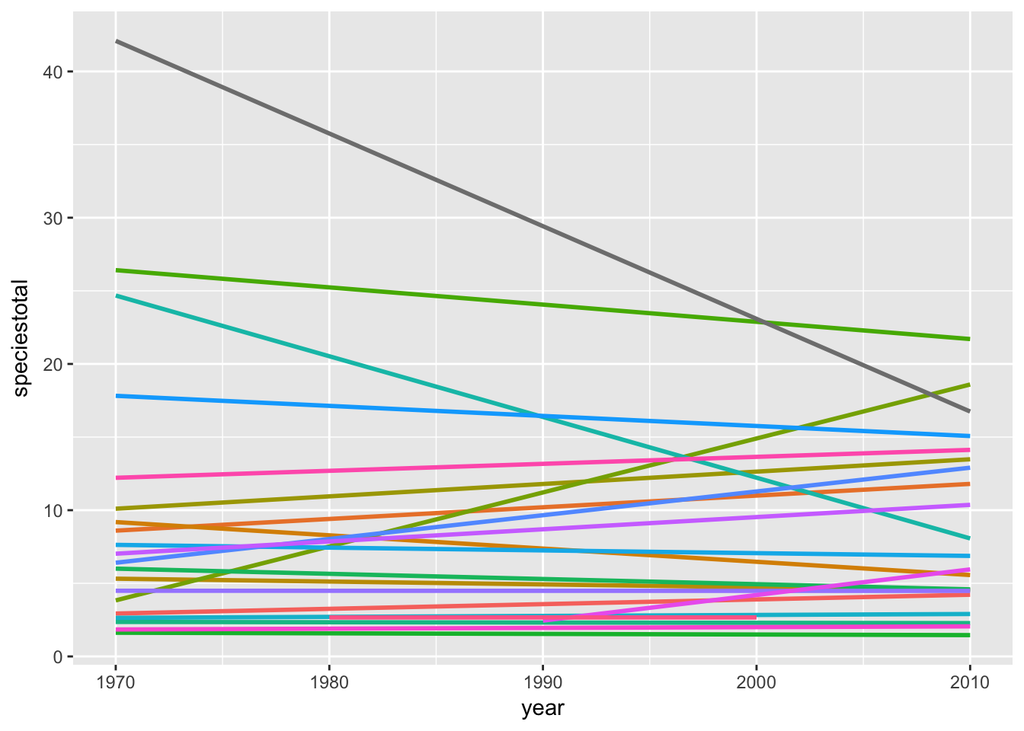

```r
ggplot(jointable,aes(x= year, y=speciestotal, color=sporder))+geom_smooth(method=lm,se = FALSE)+ theme(legend.position="none")
```